# Statistical software for climate: extRemes, climextRemes, and NIMBLE

Part 2: Introduction to NIMBLE

Chris Paciorek

July 2019

# What is NIMBLE?

- A flexible extension of the BUGS and JAGS systems
- A system for using algorithms on hierarchical statistical models
- A system for programming algorithms to be used on hierarchical models
- A partial compiler for math, flow control, and related syntax in R

We have an extensive website (r-nimble.org) with fairly comprehensive User Manual, examples, and other information.

# Why NIMBLE?

Here are some of the features you can do in NIMBLE that we are most excited about and that distinguish NIMBLE from other software:

- customize your MCMCs, including choosing what parameters to block
- define your own distributions and functions for use in BUGS code
- use a variety of algorithms on your model, including MCMC, sequential Monte Carlo (particle filtering), and MCEM
- write an algorithm in our system for easy dissemination to others, including your own MCMC sampler
- compile mathematical operations in R without needing to know or write C or C++

# Why Not NIMBLE?

- For MCMCs that rely heavily on Gibbs sampling, JAGS may be a bit faster because of more efficient internal implementation of the calculations.
- For certain model structures, Hamiltonian Monte Carlo, such as implemented in Stan, may work better than the default MCMC samplers in NIMBLE (but in a number of examples we’ve tried we’ve been able to achieve comparable or better performance either out-of-the-box or with some relatively simple modifications to the model or the MCMC samplers).
- NIMBLE can take a long time to build models that have tens of thousands or more nodes (though once built, the algorithm run times can be quite good). We anticipate big improvements in future versions of NIMBLE.

# The BUGS language

The BUGS language is described in detail in the NIMBLE manual and in the [relevant section of the BUGS manual](http://www.openbugs.net/Manuals/ModelSpecification.html).

### Stochastic declarations

- `x ~ dgamma(shape, scale)` (`x` follows a gamma distribution with parameters `shape` and `scale`)

### Deterministic declarations

- `y <- 2 * x`

### For loops

- `for(i in 1:10) {x[i] <- exp(y[i])}`

### Classic BUGS examples

There are lots of example models originally provided by the BUGS project:

- included in NIMBLE or found here on the [JAGS website](https://sourceforge.net/projects/mcmc-jags/files/Examples/).
- Information: [Volume 1](http://www.mrc-bsu.cam.ac.uk/wp-content/uploads/WinBUGS_Vol1.pdf), [Volume 2](http://www.mrc-bsu.cam.ac.uk/wp-content/uploads/WinBUGS_Vol2.pdf), and [Volume 3](http://www.mrc-bsu.cam.ac.uk/wp-content/uploads/WinBUGS_Vol3.pdf) of the WinBUGS example manuals.

### NIMBLE’s dialect of BUGS

- The BUGS syntax used in NIMBLE has minor differences from that used in WinBUGS, OpenBUGS and/or JAGS. We’ll see some of this as we go along.
- Also described in Section 5 of the [NIMBLE Users Manual](https://r-nimble.org/html_manual/cha-writing-models.html).

# An example hierarchical model

We’ll develop some models for precipitation data, using multiple GHCN stations from California.

Note that in these examples, I’ll assume exchangeability amongst the stations, but will not account for any spatial correlation between stations. So we’ll borrow strength across stations but not do so in a way that respects the spatial relationships.

One can build Gaussian spatial processes into models in NIMBLE using the multivariate normal distribution but I won’t cover that here.

We’ll also assume linearity of time trends (also likely a bad assumption). One could use spline basis functions instead (one would generally pre-compute the basis function matrix in R and pass into the NIMBLE model).

Let’s read the data in.

```r
load('precip.Rda')
head(totals)
```

```
##     stationID longitude latitude                    stationName  1950
## 1 USC00040343 -118.8253  36.4914 ASH MTN                        276.1
## 2 USC00041316 -122.8045  41.3111 CALLAHAN                       169.4
## 3 USC00041700 -121.2422  40.3033 CHESTER                        401.4
## 4 USC00042012 -119.5817  36.0975 CORCORAN IRRIG DIST             77.7
## 5 USC00042294 -121.7761  38.5350 DAVIS 2 WSW EXP FARM           234.9
## 6 USC00043261 -119.7072  36.9969 FRIANT GOVERNMENT CAMP         198.8
##    1951  1952  1953  1954  1955  1956  1957  1958  1959  1960  1961  1962
## 1 296.4 581.8 220.4 278.8 390.7 679.1 187.5 379.7 195.7 262.5 114.4 444.9
## 2 274.3 352.8 354.2 224.9 103.2 529.6 201.5 470.0 274.8 230.0 199.9 181.2
## 3 431.5 750.0 527.8 419.7 278.7 972.6 364.5 607.9 426.1 391.3 247.8 508.1
## 4  53.9 130.4  91.7  73.8 117.8 122.1  63.2 137.5  61.8  71.2  30.2 165.9
## 5 176.2 318.4 259.2 177.4 199.2 526.7 150.3 431.3 252.3 206.9 157.1 266.7
## 6 160.5 241.1 165.1 110.1 198.0 334.8 123.1 239.3 159.3 139.7  98.6 289.5
##    1963  1964  1965  1966  1967  1968  1969  1970  1971  1972  1973  1974
```

[output cut: 34 more lines]

```r
y <- as.matrix(totals[ , 5:ncol(totals)])
n <- as.matrix(cnts[ , 5:ncol(cnts)])
y[n < 86] <- NA
y <- y / 10  # data now in cm not mm
```

# Code the model (using BUGS syntax)

```r
code <- nimbleCode({
    for(j in 1:J) {  # stations
       for(i in 1:nYears) {  # time
           # likelihood
           y[j, i] ~ dnorm(b0[j] + b1[j] * t[i],
                     sd = exp(gamma0[j] + gamma1[j] * t[i]))
       }

       # random effects
       b0[j] ~ dnorm(mu0, sd = sigma0)
       b1[j] ~ dnorm(mu1, sd = sigma1)
       gamma0[j] ~ dnorm(theta0, sd = tau0)
       gamma1[j] ~ dnorm(theta1, sd = tau1)
   }

   # hyperpriors
   mu0 ~ dflat()
   mu1 ~ dflat()
   theta0 ~ dflat()
   theta1 ~ dflat()
   ## see Gelman (2006) for non-informative priors for variance components
   sigma0 ~ dunif(0, 100)
   sigma1 ~ dunif(0, 100)
   tau0 ~ dunif(0, 100)
   tau1 ~ dunif(0, 100)
})
```

# Building the model

The first step is to build an R representation of the model.

```r
nYears <- ncol(y)
J <- nrow(y)
tt <- 1950:2017
tt <- tt - mean(tt)  ## better MCMC mixing if covariates are centered

set.seed(1)

consts <- list(J = J, nYears = nYears, t = tt)
data <- list(y = y)
## Be careful tau1 not too big given values are multiplied by +30 and exponentiated
inits <- list(b0 = apply(y, 1, mean, na.rm = TRUE), b1 = rnorm(J, 0, 1),
                 gamma0 = log(apply(y, 1, sd, na.rm = TRUE)), gamma1 = rnorm(J, 0, 0.002),
                 mu0 = mean(y, na.rm = TRUE), mu1 = 0, theta0 = log(sd(y, na.rm = TRUE)),
                 theta1 = 0, sigma0 = 5, sigma1 = 1,
                 tau0 = 1, tau1 = 0.002)


## create the NIMBLE model object
model <- nimbleModel(code,
          data = data, constants = consts, inits = inits)
```

```
## defining model...
```

```
## building model...
```

```
## setting data and initial values...
```

```
## running calculate on model (any error reports that follow may simply reflect missing values in model variables) ...
## checking model sizes and dimensions... This model is not fully initialized. This is not an error. To see which variables are not initialized, use model$initializeInfo(). For more information on model initialization, see help(modelInitialization).
## model building finished.
```

```r
model$initializeInfo()
```

```
## Missing values (NAs) or non-finite values were found in model variables: y. This is not an error, but some or all variables may need to be initialized for certain algorithms to operate properly. For more information on model initialization, see help(modelInitialization).
```

# Compiling a model

In general, you’ll want a version of the model that allows for fast computation (this can then be used by any algorithms you use on the model).

To create a fast compiled version of the model, you simply do this.

```r
cModel <- compileNimble(model)
```

```
## compiling... this may take a minute. Use 'showCompilerOutput = TRUE' to see C++ compilation details.
```

```
## compilation finished.
```

# Fit the model using MCMC - overview

In BUGS, JAGS or Stan, one would provide the model code, input data and constant values, and (optionally) initial parameter values and the software would directly create and run an MCMC, returning the results to you.

In NIMBLE, you have more fine-grained control over these steps.

The steps of running an MCMC are as follows:

1. configure the MCMC
2. build the MCMC
3. create a compiled version of the MCMC
4. run the MCMC
5. assess and use the MCMC samples

If all you want to do is run an MCMC, NIMBLE’s fine-grained control might not be so interesting to you, in which case you can just use `nimbleMCMC()` without using `nimbleModel()` to create the model. But by providing an explicit model object, we allow you to operate the model and program with it.

# Configuring a basic MCMC

Setting up and running an MCMC in NIMBLE in this way takes a few more steps than in BUGS or JAGS, but with the benefit of giving the user much more control of how the MCMC operates.

First we *configure* the MCMC, which means setting up the samplers to be used for each node or group of nodes. NIMBLE provides a default configuration, but we’ll see shortly how you can modify that.

```r
conf <- configureMCMC(model)
```

You also specify the nodes for which you’d like to get the MCMC samples as output. By default hyperparameters, but not random effects/latent process values, are monitored.

```r
conf$addMonitors(c('b0', 'b1', 'gamma0', 'gamma1'))
```

```
## thin = 1: mu0, mu1, theta0, theta1, sigma0, sigma1, tau0, tau1, b0, b1, gamma0, gamma1
```

Let’s see the samplers assigned:

```r
conf$printSamplers()
```

```
## [1]   conjugate_dflat_dnorm sampler: mu0
## [2]   conjugate_dflat_dnorm sampler: mu1
## [3]   conjugate_dflat_dnorm sampler: theta0
## [4]   conjugate_dflat_dnorm sampler: theta1
## [5]   RW sampler: sigma0
## [6]   RW sampler: sigma1
## [7]   RW sampler: tau0
## [8]   RW sampler: tau1
## [9]   conjugate_dnorm_dnorm sampler: b0[1]
## [10]  conjugate_dnorm_dnorm sampler: b0[2]
## [11]  conjugate_dnorm_dnorm sampler: b0[3]
## [12]  conjugate_dnorm_dnorm sampler: b0[4]
## [13]  conjugate_dnorm_dnorm sampler: b0[5]
## [14]  conjugate_dnorm_dnorm sampler: b0[6]
## [15]  conjugate_dnorm_dnorm sampler: b0[7]
```

[output cut: 182 more lines]

# Building the MCMC algorithm for the model

Next we’ll build the MCMC algorithm for the model under the default configuration. And we’ll create a compiled (i.e., C++) version of the MCMC that is equivalent in functionality but will run much faster.

```r
MCMC <- buildMCMC(conf)
cMCMC <- compileNimble(MCMC, project = model)
```

```
## compiling... this may take a minute. Use 'showCompilerOutput = TRUE' to see C++ compilation details.
```

```
## compilation finished.
```

# Running the MCMC

Now let’s run the MCMC. We don’t recommend running the R version of the MCMC for very many iterations - it’s really slow - in part because iterating in R is slow and in part because iterating with a model in NIMBLE requires even more overhead.

```r
niter <- 11000
nburn <- 1000
thin <- 20
set.seed(1)

samples <- runMCMC(cMCMC, niter = niter, nburnin = nburn, thin = thin, setSeed = 1)
```

```
## runMCMC's handling of nburnin changed in nimble version 0.6-11. Previously, nburnin samples were discarded *post-thinning*.  Now nburnin samples are discarded *pre-thinning*.  The number of samples returned will be floor((niter-nburnin)/thin).
```

```
## running chain 1...
```

```
## |-------------|-------------|-------------|-------------|
## |-------------------------------------------------------|
```

Now let’s look at the MCMC performance of this initial chain.

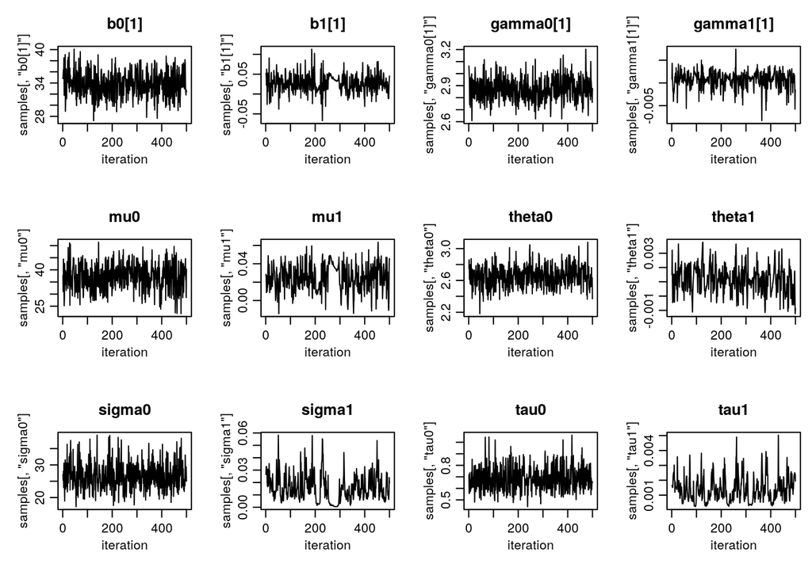

```r
par(mfrow = c(3, 4), mai = c(.6, .5, .4, .1), mgp = c(1.8, 0.7, 0))
ts.plot(samples[ , 'b0[1]'], xlab = 'iteration', main = 'b0[1]')
ts.plot(samples[ , 'b1[1]'], xlab = 'iteration', main = 'b1[1]')
ts.plot(samples[ , 'gamma0[1]'], xlab = 'iteration', main = 'gamma0[1]')
ts.plot(samples[ , 'gamma1[1]'], xlab = 'iteration', main = 'gamma1[1]')
ts.plot(samples[ , 'mu0'], xlab = 'iteration', main = 'mu0')
ts.plot(samples[ , 'mu1'], xlab = 'iteration', main = 'mu1')
ts.plot(samples[ , 'theta0'], xlab = 'iteration', main = 'theta0')
ts.plot(samples[ , 'theta1'], xlab = 'iteration', main = 'theta1')
ts.plot(samples[ , 'sigma0'], xlab = 'iteration', main = 'sigma0')
ts.plot(samples[ , 'sigma1'], xlab = 'iteration', main = 'sigma1')
ts.plot(samples[ , 'tau0'], xlab = 'iteration', main = 'tau0')
ts.plot(samples[ , 'tau1'], xlab = 'iteration', main = 'tau1')
```

In general to assess mixing it’s a good idea to run multiple chains from over-dispersed starting values. So we create a function that will generate initial values, based on some understanding of where we think the posterior is concentrated (yes, this is somewhat circular…).

```r
## decide once see initial samples
initsFun <- function() {
      mu0 <- runif(1, 30, 40)
      mu1 <- runif(1, -.1, .1)
      theta0 <- runif(1, 2, 3.5)
      theta1 <- runif(1, -.1, .1)
      sigma0 <- runif(1, 15, 40)
      sigma1 <- runif(1, 0, 0.1)
      tau0 <- runif(1, 0.3, 1.5)
      tau1 <- runif(1, 0, .005)
      b0 <- rnorm(J, mu0, sigma0)
      b1 <- rnorm(J, mu1, sigma1)
      gamma0 <- rnorm(J, theta0, tau0)
      gamma1 <- rnorm(J, theta1, tau1)
      return(list(mu0 = mu0, mu1 = mu1, theta0 = theta0, theta1 = theta1, sigma0 = sigma0, sigma1 = sigma1,
      tau0 = tau0, tau1 = tau1, b0 = b0, b1 = b1, gamma0 = gamma0, gamma1 = gamma1))
}
samples <- runMCMC(cMCMC, niter = niter, nburnin = nburn, thin = thin,
                          inits = initsFun, nchains = 3, setSeed = TRUE,
                          samplesAsCodaMCMC = TRUE)
```

```
## runMCMC's handling of nburnin changed in nimble version 0.6-11. Previously, nburnin samples were discarded *post-thinning*.  Now nburnin samples are discarded *pre-thinning*.  The number of samples returned will be floor((niter-nburnin)/thin).
```

```
## running chain 1...
```

```
## |-------------|-------------|-------------|-------------|
## |-------------------------------------------------------|
```

```
## running chain 2...
```

```
## |-------------|-------------|-------------|-------------|
## |-------------------------------------------------------|
```

```
## running chain 3...
```

```
## |-------------|-------------|-------------|-------------|
## |-------------------------------------------------------|
```

# Using CODA

NIMBLE does not provide any MCMC diagnostics. (At least not yet; there’s no reason one couldn’t write code for various diagnostics using the NIMBLE system.) But one can easily use CODA or other R packages with the MCMC output from a NIMBLE MCMC.

```r
library(coda, warn.conflicts = FALSE)
crosscorr(samples[[1]][ , c('mu0', 'mu1', 'sigma0', 'sigma1',
                          'theta0', 'theta1', 'tau0', 'tau1')])
```

```
##                mu0         mu1        sigma0        sigma1       theta0
## mu0     1.00000000  0.01721386  5.346899e-02  0.0630677633 -0.037541334
## mu1     0.01721386  1.00000000  1.019307e-02  0.2398958866 -0.035373549
## sigma0  0.05346899  0.01019307  1.000000e+00 -0.0004254372  0.043037289
## sigma1  0.06306776  0.23989589 -4.254372e-04  1.0000000000 -0.023078180
## theta0 -0.03754133 -0.03537355  4.303729e-02 -0.0230781796  1.000000000
## theta1 -0.03016217 -0.16908982  8.673412e-03 -0.1048552534  0.020822284
## tau0   -0.07067244  0.02675309  9.033958e-05  0.0187774816  0.007677084
## tau1    0.06322529 -0.03282667  1.588119e-02  0.1289300823 -0.015621778
##              theta1          tau0        tau1
## mu0    -0.030162171 -7.067244e-02  0.06322529
## mu1    -0.169089821  2.675309e-02 -0.03282667
## sigma0  0.008673412  9.033958e-05  0.01588119
## sigma1 -0.104855253  1.877748e-02  0.12893008
## theta0  0.020822284  7.677084e-03 -0.01562178
## theta1  1.000000000  4.385991e-02 -0.08214776
## tau0    0.043859908  1.000000e+00  0.02406560
## tau1   -0.082147763  2.406560e-02  1.00000000
```

```r
effectiveSize(samples[[1]])  ## ESS
```

```
##      b0[1]      b0[2]      b0[3]      b0[4]      b0[5]      b0[6]
##  500.00000  500.00000  500.00000  500.00000  377.29660  372.24800
##      b0[7]      b0[8]      b0[9]     b0[10]     b0[11]     b0[12]
##  351.51746  500.00000  500.00000  500.00000  576.26673  425.73047
##     b0[13]     b0[14]     b0[15]     b0[16]     b0[17]     b0[18]
##  500.00000  500.00000  500.00000  500.00000  500.00000  500.00000
##     b0[19]     b0[20]     b0[21]     b0[22]     b0[23]     b0[24]
##  577.78672  500.00000  500.00000  601.26912  500.00000  500.00000
##     b0[25]     b0[26]      b1[1]      b1[2]      b1[3]      b1[4]
##  500.00000  585.18991  421.43009  391.08368  500.00000  215.47855
##      b1[5]      b1[6]      b1[7]      b1[8]      b1[9]     b1[10]
##  386.13931  233.64930  500.00000  392.90106  426.77137  321.31449
##     b1[11]     b1[12]     b1[13]     b1[14]     b1[15]     b1[16]
##  273.36374  500.00000  230.49711  500.00000  424.10547  261.32556
##     b1[17]     b1[18]     b1[19]     b1[20]     b1[21]     b1[22]
##  500.00000  475.48745  500.00000  290.81027  264.73577  175.24565
##     b1[23]     b1[24]     b1[25]     b1[26]  gamma0[1]  gamma0[2]
##  380.04417  183.72451  220.50703  189.20750  500.00000  449.97050
##  gamma0[3]  gamma0[4]  gamma0[5]  gamma0[6]  gamma0[7]  gamma0[8]
##  500.00000  406.38724  500.00000  500.00000  407.27414  410.23001
##  gamma0[9] gamma0[10] gamma0[11] gamma0[12] gamma0[13] gamma0[14]
##  519.19927  500.00000  500.00000  500.00000  500.00000  500.00000
## gamma0[15] gamma0[16] gamma0[17] gamma0[18] gamma0[19] gamma0[20]
##  510.25233  500.00000  500.00000  500.00000  500.00000  381.69150
## gamma0[21] gamma0[22] gamma0[23] gamma0[24] gamma0[25] gamma0[26]
##  500.00000  500.00000  500.00000  500.00000  500.00000  500.00000
##  gamma1[1]  gamma1[2]  gamma1[3]  gamma1[4]  gamma1[5]  gamma1[6]
##  135.23860  233.52518  194.09639  337.78021  266.45613  144.85957
##  gamma1[7]  gamma1[8]  gamma1[9] gamma1[10] gamma1[11] gamma1[12]
##  285.22737  281.11450  276.97995  229.46938  389.86664   58.63152
## gamma1[13] gamma1[14] gamma1[15] gamma1[16] gamma1[17] gamma1[18]
##  329.07394  191.15505  138.02647  275.71058  378.76286  307.96108
## gamma1[19] gamma1[20] gamma1[21] gamma1[22] gamma1[23] gamma1[24]
##  224.19269  379.97007  346.22604  239.09495  146.40431  284.57200
## gamma1[25] gamma1[26]        mu0        mu1     sigma0     sigma1
##  178.08666  268.67507  500.00000  161.60087  500.00000  110.44662
##       tau0       tau1     theta0     theta1
##  500.00000   17.39004  500.00000  125.98454
```

To apply the commonly used Gelman-Rubin potential scale reduction factor diagnostic, we’ll need the multiple chains.

Considerations: you’ll want to think about how to set up the over-dispersed starting points and the number of iterations to use for burn-in.

# Assessing MCMC performance from multiple chains

```r
par(mfrow = c(1,2))
gelman.diag(samples)
```

```
## Potential scale reduction factors:
##
##            Point est. Upper C.I.
## b0[1]           1.002      1.009
## b0[2]           1.000      1.006
## b0[3]           0.999      1.002
## b0[4]           1.003      1.012
## b0[5]           1.004      1.006
## b0[6]           1.005      1.009
## b0[7]           1.003      1.016
## b0[8]           1.003      1.012
## b0[9]           1.006      1.023
## b0[10]          1.002      1.005
## b0[11]          1.003      1.012
## b0[12]          1.004      1.008
## b0[13]          1.000      1.002
## b0[14]          1.001      1.003
## b0[15]          1.007      1.026
## b0[16]          1.002      1.014
## b0[17]          1.009      1.013
## b0[18]          1.000      1.002
## b0[19]          1.001      1.006
## b0[20]          1.002      1.013
## b0[21]          0.999      1.001
## b0[22]          1.002      1.008
## b0[23]          1.007      1.029
## b0[24]          1.000      1.001
## b0[25]          1.000      1.004
## b0[26]          1.000      1.004
## b1[1]           1.004      1.012
## b1[2]           1.008      1.015
## b1[3]           1.002      1.002
## b1[4]           1.003      1.010
## b1[5]           1.000      1.003
## b1[6]           1.000      1.004
## b1[7]           1.004      1.004
## b1[8]           1.001      1.006
## b1[9]           1.003      1.016
## b1[10]          1.009      1.019
## b1[11]          0.999      1.001
```

[output cut: 64 more lines]

```
## gamma1[24]      1.017      1.026
## gamma1[25]      1.039      1.064
## gamma1[26]      1.025      1.049
## mu0             1.003      1.005
## mu1             1.001      1.005
## sigma0          1.002      1.006
## sigma1          1.013      1.052
## tau0            1.002      1.004
## tau1            1.116      1.341
## theta0          1.001      1.004
## theta1          1.015      1.035
##
## Multivariate psrf
##
## 1.18
```

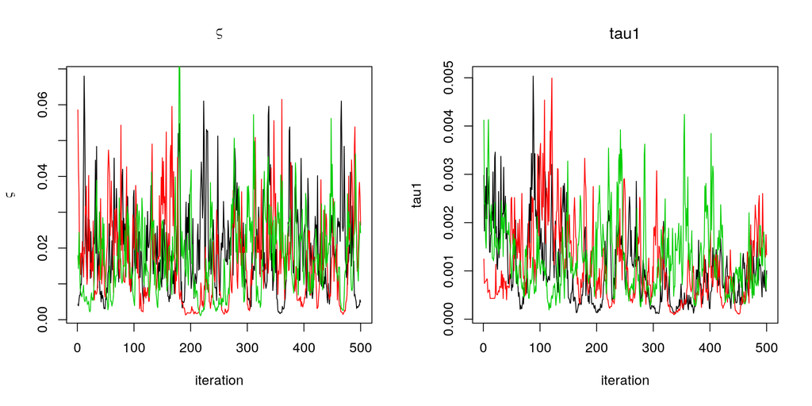

```r
## and here's a graphical representation of the information
ts.plot(samples[[1]][ , 'sigma1'], xlab = 'iteration',
     ylab = expression(sigma1), main = expression(sigma1))
sq <- seq_along(samples[[1]][ , 'sigma1'])
for(i in 2:3)
      lines(sq, samples[[i]][ , 'sigma1'], col = i)

ts.plot(samples[[1]][ , 'tau1'], xlab = 'iteration',
     ylab = expression(tau1), main = expression(tau1))
sq <- seq_along(samples[[1]][ , 'tau1'])
for(i in 2:3)
      lines(sq, samples[[i]][ , 'tau1'], col = i)
```

# Customizing samplers

As those who’ve worked with MCMC before know, MCMC is a family of algorithms and there are many ways to run an MCMC for any given model, including the choice of the kind of sampler used for each parameter in the model.

One of NIMBLE’s most important features is that users can easily modify the MCMC algorithm used for their model. The easiest thing to do is to start with NIMBLE’s default MCMC and then make modifications.

```r
hypers <- c('sigma0', 'sigma1', 'tau0', 'tau1')
confSlice <- configureMCMC(model)
confSlice$addMonitors(c('b0','b1','gamma0','gamma1'))
```

```
## thin = 1: mu0, mu1, theta0, theta1, sigma0, sigma1, tau0, tau1, b0, b1, gamma0, gamma1
```

```r
for(h in hypers) {
      confSlice$removeSamplers(h)
      confSlice$addSampler(target = h, type = 'slice')
}
confSlice$printSamplers()
```

```
## [1]   conjugate_dflat_dnorm sampler: mu0
## [2]   conjugate_dflat_dnorm sampler: mu1
## [3]   conjugate_dflat_dnorm sampler: theta0
## [4]   conjugate_dflat_dnorm sampler: theta1
## [5]   conjugate_dnorm_dnorm sampler: b0[1]
## [6]   conjugate_dnorm_dnorm sampler: b0[2]
## [7]   conjugate_dnorm_dnorm sampler: b0[3]
## [8]   conjugate_dnorm_dnorm sampler: b0[4]
## [9]   conjugate_dnorm_dnorm sampler: b0[5]
## [10]  conjugate_dnorm_dnorm sampler: b0[6]
## [11]  conjugate_dnorm_dnorm sampler: b0[7]
## [12]  conjugate_dnorm_dnorm sampler: b0[8]
## [13]  conjugate_dnorm_dnorm sampler: b0[9]
## [14]  conjugate_dnorm_dnorm sampler: b0[10]
## [15]  conjugate_dnorm_dnorm sampler: b0[11]
```

[output cut: 182 more lines]

```r
MCMC <- buildMCMC(confSlice)
## we need 'resetFunctions' because we are rebuilding the MCMC for an existing model
cMCMC <- compileNimble(MCMC, project = model, resetFunctions = TRUE)
```

```
## compiling... this may take a minute. Use 'showCompilerOutput = TRUE' to see C++ compilation details.
```

```
## compilation finished.
```

```r
samplesSlice <- runMCMC(cMCMC, niter = niter, nburnin = nburn, thin = thin,
             inits = inits, nchains = 1, setSeed = 1, samplesAsCodaMCMC = FALSE)
```

```
## runMCMC's handling of nburnin changed in nimble version 0.6-11. Previously, nburnin samples were discarded *post-thinning*.  Now nburnin samples are discarded *pre-thinning*.  The number of samples returned will be floor((niter-nburnin)/thin).
```

```
## running chain 1...
```

```
## |-------------|-------------|-------------|-------------|
## |-------------------------------------------------------|
```

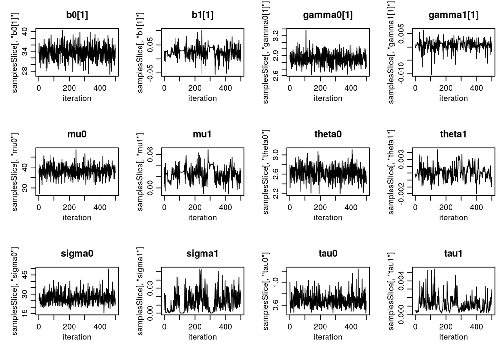

```r
par(mfrow = c(3, 4), mai = c(.6, .5, .4, .1), mgp = c(1.8, 0.7, 0))
ts.plot(samplesSlice[ , 'b0[1]'], xlab = 'iteration', main = 'b0[1]')
ts.plot(samplesSlice[ , 'b1[1]'], xlab = 'iteration', main = 'b1[1]')
ts.plot(samplesSlice[ , 'gamma0[1]'], xlab = 'iteration', main = 'gamma0[1]')
ts.plot(samplesSlice[ , 'gamma1[1]'], xlab = 'iteration', main = 'gamma1[1]')
ts.plot(samplesSlice[ , 'mu0'], xlab = 'iteration', main = 'mu0')
ts.plot(samplesSlice[ , 'mu1'], xlab = 'iteration', main = 'mu1')
ts.plot(samplesSlice[ , 'theta0'], xlab = 'iteration', main = 'theta0')
ts.plot(samplesSlice[ , 'theta1'], xlab = 'iteration', main = 'theta1')
ts.plot(samplesSlice[ , 'sigma0'], xlab = 'iteration', main = 'sigma0')
ts.plot(samplesSlice[ , 'sigma1'], xlab = 'iteration', main = 'sigma1')
ts.plot(samplesSlice[ , 'tau0'], xlab = 'iteration', main = 'tau0')
ts.plot(samplesSlice[ , 'tau1'], xlab = 'iteration', main = 'tau1')
```

```r
effectiveSize(samplesSlice)  # ESS
```

```
##      b0[1]      b0[2]      b0[3]      b0[4]      b0[5]      b0[6]
##  578.45202  505.11647  500.00000  500.00000  500.00000  509.63300
##      b0[7]      b0[8]      b0[9]     b0[10]     b0[11]     b0[12]
##  567.87578  500.00000  500.00000  360.18537  630.29111  500.00000
##     b0[13]     b0[14]     b0[15]     b0[16]     b0[17]     b0[18]
##  500.00000  544.59331  500.00000  500.00000  500.00000  500.00000
##     b0[19]     b0[20]     b0[21]     b0[22]     b0[23]     b0[24]
##  500.00000  265.47152  500.00000  427.82626  500.00000  500.00000
##     b0[25]     b0[26]      b1[1]      b1[2]      b1[3]      b1[4]
##  500.00000  500.00000  224.12488  112.02695   97.53366  207.12605
##      b1[5]      b1[6]      b1[7]      b1[8]      b1[9]     b1[10]
##  154.82993  179.39597  107.93104  139.03855  112.05694  108.92619
##     b1[11]     b1[12]     b1[13]     b1[14]     b1[15]     b1[16]
##  150.55510   73.12580  190.95547  123.86193  161.63435  121.71487
##     b1[17]     b1[18]     b1[19]     b1[20]     b1[21]     b1[22]
##  244.55671  185.19577   90.19671  176.67523  270.75357   62.31620
##     b1[23]     b1[24]     b1[25]     b1[26]  gamma0[1]  gamma0[2]
##  228.51799  225.14550  259.01548  188.74486  500.00000  500.00000
##  gamma0[3]  gamma0[4]  gamma0[5]  gamma0[6]  gamma0[7]  gamma0[8]
##  500.00000  414.65287  500.00000  500.00000  594.90074  500.00000
##  gamma0[9] gamma0[10] gamma0[11] gamma0[12] gamma0[13] gamma0[14]
##  425.98173  500.00000  500.00000  586.47550  500.00000  569.93012
## gamma0[15] gamma0[16] gamma0[17] gamma0[18] gamma0[19] gamma0[20]
##  513.08797  500.00000  594.30112  500.00000  500.00000  500.00000
## gamma0[21] gamma0[22] gamma0[23] gamma0[24] gamma0[25] gamma0[26]
##  500.00000  371.64716  500.00000  601.56715  590.12802  500.00000
##  gamma1[1]  gamma1[2]  gamma1[3]  gamma1[4]  gamma1[5]  gamma1[6]
##  188.80888  131.56995  247.58747  247.50530  206.35457  293.29016
##  gamma1[7]  gamma1[8]  gamma1[9] gamma1[10] gamma1[11] gamma1[12]
##  267.36363  151.10439  156.39186  152.69953  248.49006  304.11460
## gamma1[13] gamma1[14] gamma1[15] gamma1[16] gamma1[17] gamma1[18]
##  254.71660  325.15530  195.36724  195.41619  221.55480  283.23257
## gamma1[19] gamma1[20] gamma1[21] gamma1[22] gamma1[23] gamma1[24]
##  226.66527  282.51494  332.26003  128.63512  274.20544  219.46393
## gamma1[25] gamma1[26]        mu0        mu1     sigma0     sigma1
##  298.98754  263.51797  636.62792   65.20870  500.00000   44.38210
##       tau0       tau1     theta0     theta1
##  500.00000   90.34325  500.00000  111.66521
```

Ok, so not clear that helped much, particularly given the slice sampler is rather slower per iteration than Metropolis sampling.

The basic problem here is that the variance components can get trapped near zero because of the dependence between a variance component and its associated random effects.

# WAIC for model selection

We could assess whether allowing for a trend in the year-to-year variance is needed.

This would involve:

```r
conf <- configureMCMC(model, enableWAIC = TRUE)
conf$addMonitors(c('b0','b1','gamma0','gamma1'))
```

```
## thin = 1: mu0, mu1, theta0, theta1, sigma0, sigma1, tau0, tau1, b0, b1, gamma0, gamma1
```

```r
MCMC <- buildMCMC(conf)
```

```
## Monitored nodes are valid for WAIC
```

```r
cMCMC <- compileNimble(MCMC, project = model, resetFunctions = TRUE)
```

```
## compiling... this may take a minute. Use 'showCompilerOutput = TRUE' to see C++ compilation details.
```

```
## compilation finished.
```

```r
niter <- 10000
nburn <- 1000
thin <- 1
set.seed(1)

out <- runMCMC(cMCMC, niter = niter, nburnin = nburn, thin = thin, WAIC = TRUE)
```

```
## running chain 1...
```

```
## |-------------|-------------|-------------|-------------|
## |-------------------------------------------------------|
```

```r
samples <- out$samples
out$WAIC
```

```
## [1] 13741.96
```

We would then want to fit a model without any variability in `gamma1` to compare against the WAIC for the base model. We could do that together or as a break-out exercise.

# Breakout

Play around with the code shown above or fit an alternative model or write up a model for some of your own data.